# Breast Cancer Recurrence Statistical Analysis

Elham Morshedi

# Research Scenario and Questions

Breast cancer is a significant global health concern, and understanding factors that may lead to recurrence is vital for patient care and treatment planning. This project investigates the relationships between various patient characteristics and tumor features with breast cancer recurrence using the UCI Machine Learning Repository’s Breast Cancer dataset.

## Dataset Description

The dataset contains information from breast cancer patients, including demographic information, tumor characteristics, and whether recurrence occurred. The variables include:

1. **Class**: Target variable - no-recurrence-events or recurrence-events
2. **Age**: Patient’s age in categories (20-29, 30-39, 40-49, 50-59, 60-69, 70-79)
3. **Menopause**: Menopause status (lt40, ge40, premeno)
4. **Tumor_Size**: Size of tumor in categories (0-4cm, 5-9cm, etc.)
5. **Inv_Nodes**: Number of positive axillary lymph nodes (0-2, 3-5, 6-8, etc.)
6. **Node_Caps**: Whether caps of lymph nodes are penetrated (yes, no)
7. **Deg_Malig**: Degree of malignancy (1, 2, 3)
8. **Breast**: Left or right breast
9. **Breast_Quad**: Quadrant of the breast (left-up, left-low, right-up, right-low, central)
10. **Irradiat**: Whether the patient received radiation therapy (yes, no)

## Research Questions

Below are 12 research questions organized by module, covering various statistical concepts:

### Module 1: Descriptive Statistics and Normal Distribution

- **Question 1**: What are the summary statistics for tumor size in patients with and without recurrence? Is there evidence that tumor size follows a normal distribution in each group?
- **Question 2**: What is the probability that a patient from this dataset has a tumor size greater than 4cm, assuming tumor sizes follow a normal distribution?

### Module 2: Statistical Inference and Hypothesis Testing

- **Question 3**: Is there a significant difference in tumor size between patients who experienced recurrence and those who did not?
- **Question 4**: Is there a significant difference in the number of invasive nodes between patients who received radiation therapy and those who did not?

### Module 3: Correlation and Simple Linear Regression

- **Question 5**: Is there a correlation between tumor size and the number of invasive nodes? How strong is this relationship?
- **Question 6**: Can we predict the degree of malignancy based on tumor size using simple linear regression?

### Module 4: Multiple Linear Regression

- **Question 7**: Can we predict the number of invasive nodes based on tumor size, degree of malignancy, and age group?
- **Question 8**: Which combination of variables best predicts tumor size in this dataset?

### Module 5: Analysis of Variance (ANOVA)

- **Question 9**: Is there a significant difference in tumor size across different age groups?
- **Question 10**: Is there a significant difference in the degree of malignancy across different breast quadrants, controlling for age?

### Module 6: Logistic Regression and Proportions

- **Question 11**: What is the proportion of patients receiving radiation therapy who experienced recurrence? Does this proportion differ significantly from those not receiving radiation therapy?
- **Question 12**: Can we predict cancer recurrence based on tumor size, invasive nodes, and degree of malignancy using logistic regression? How accurate is this model?

# Data Import and Preprocessing

The dataset was imported from the UCI repository and preprocessed to handle categorical variables and missing values.

```r
# Load the dataset from UCI Machine Learning Repository
url <- "https://archive.ics.uci.edu/ml/machine-learning-databases/breast-cancer/breast-cancer.data"

column_names <- c("Class", "Age", "Menopause", "Tumor_Size", "Inv_Nodes",
                  "Node_Caps", "Deg_Malig", "Breast", "Breast_Quad", "Irradiat")

bc_data <- read.csv(url, header = FALSE, col.names = column_names, na.strings = "?")

# Convert Class to binary (1 = recurrence, 0 = no recurrence)
bc_data$Recurrence <- ifelse(bc_data$Class == "recurrence-events", 1, 0)

# Convert categorical variables to factors
bc_data$Age <- as.factor(bc_data$Age)
bc_data$Menopause <- as.factor(bc_data$Menopause)
bc_data$Node_Caps <- as.factor(bc_data$Node_Caps)
bc_data$Breast <- as.factor(bc_data$Breast)
bc_data$Breast_Quad <- as.factor(bc_data$Breast_Quad)
bc_data$Irradiat <- as.factor(bc_data$Irradiat)

# Convert tumor size to numeric (extract midpoint of range)
bc_data$Tumor_Size_Numeric <- NA
for(i in 1:nrow(bc_data)) {
  size_range <- bc_data$Tumor_Size[i]
  numbers <- as.numeric(unlist(strsplit(gsub("cm", "", size_range), "-")))
  if(length(numbers) == 2) {
    bc_data$Tumor_Size_Numeric[i] <- mean(numbers)
  }
}

# Convert invasive nodes to numeric
bc_data$Inv_Nodes_Numeric <- NA
for(i in 1:nrow(bc_data)) {
  node_range <- bc_data$Inv_Nodes[i]
  numbers <- as.numeric(unlist(strsplit(node_range, "-")))
  if(length(numbers) == 2) {
    bc_data$Inv_Nodes_Numeric[i] <- mean(numbers)
  }
}

# Handle missing values
bc_data <- na.omit(bc_data)

cat("Dataset dimensions:", dim(bc_data), "\n")
```

```
## Dataset dimensions: 277 13
```

```r
cat("Number of patients:", nrow(bc_data), "\n")
```

```
## Number of patients: 277
```

```r
cat("Number of variables:", ncol(bc_data), "\n")
```

```
## Number of variables: 13
```

# Module 1: Descriptive Statistics and Normal Distribution

## Question 1: Summary Statistics and Normality of Tumor Size by Recurrence Status

```r
# Separate data by recurrence status
recurrence_yes <- bc_data[bc_data$Recurrence == 1, ]
recurrence_no <- bc_data[bc_data$Recurrence == 0, ]

# Summary statistics
summary_yes <- summary(recurrence_yes$Tumor_Size_Numeric)
summary_no <- summary(recurrence_no$Tumor_Size_Numeric)
sd_yes <- sd(recurrence_yes$Tumor_Size_Numeric)
sd_no <- sd(recurrence_no$Tumor_Size_Numeric)

cat("Summary statistics for tumor size in patients WITH recurrence:\n")
```

```
## Summary statistics for tumor size in patients WITH recurrence:
```

```r
print(summary_yes)
```

```
##    Min. 1st Qu.  Median    Mean 3rd Qu.    Max.
##    2.00   22.00   32.00   29.53   32.00   52.00
```

```r
cat("Standard deviation:", round(sd_yes, 2), "\n\n")
```

```
## Standard deviation: 8.81
```

```r
cat("Summary statistics for tumor size in patients WITHOUT recurrence:\n")
```

```
## Summary statistics for tumor size in patients WITHOUT recurrence:
```

```r
print(summary_no)
```

```
##    Min. 1st Qu.  Median    Mean 3rd Qu.    Max.
##    2.00   17.00   27.00   25.11   32.00   52.00
```

```r
cat("Standard deviation:", round(sd_no, 2), "\n\n")
```

```
## Standard deviation: 11.11
```

```r
# Test for normality (Shapiro-Wilk test)
normality_yes <- shapiro.test(recurrence_yes$Tumor_Size_Numeric)
normality_no <- shapiro.test(recurrence_no$Tumor_Size_Numeric)

cat("Shapiro-Wilk test for normality (WITH recurrence):\n")
```

```
## Shapiro-Wilk test for normality (WITH recurrence):
```

```r
cat("W =", round(normality_yes$statistic, 5), ", p-value =", round(normality_yes$p.value, 6), "\n\n")
```

```
## W = 0.94821 , p-value = 0.002529
```

```r
cat("Shapiro-Wilk test for normality (WITHOUT recurrence):\n")
```

```
## Shapiro-Wilk test for normality (WITHOUT recurrence):
```

```r
cat("W =", round(normality_no$statistic, 5), ", p-value =", round(normality_no$p.value, 7), "\n")
```

```
## W = 0.97139 , p-value = 0.0004924
```

### Key Findings

This non-normal distribution suggests that parametric tests assuming normality may not be appropriate for comparing these groups, and non-parametric alternatives should be considered for further analysis of tumor size between recurrence groups.

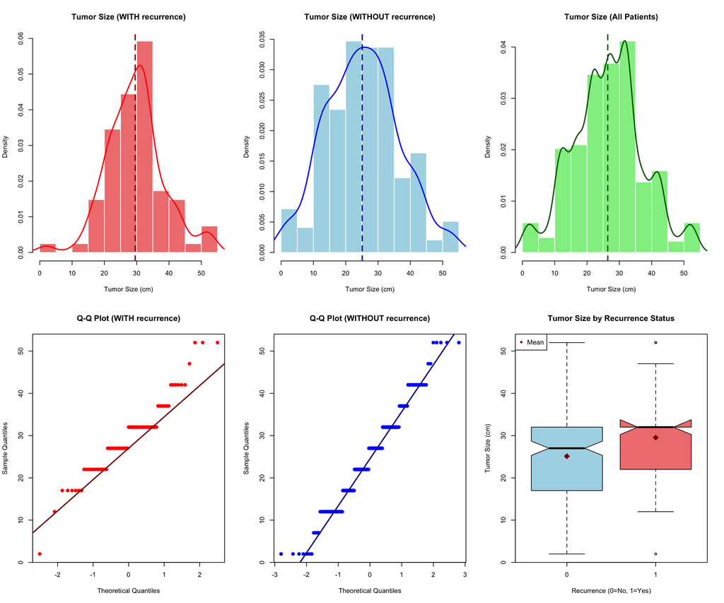

### Visual Interpretation

The Q-Q plots for both groups show deviations from the diagonal line that would indicate perfect normality. This visual evidence supports the Shapiro-Wilk test results. The boxplot shows the difference in distributions between the two groups, with the recurrence group (1) having a slightly higher median and mean (represented by the diamond marker) than the non-recurrence group (0), though there is substantial overlap between the groups.

Table 1: Tumor Size Characteristics by Recurrence Status

| Statistic | Recurrence Group | No Recurrence Group |
| --- | --- | --- |
| Sample Size | 81 | 196 |
| Mean (cm) | 29.53 | 25.11 |
| Median (cm) | 32 | 27 |
| Standard Deviation | 8.81 | 11.11 |
| Minimum (cm) | 2 | 2 |
| Maximum (cm) | 52 | 52 |
| Shapiro-Wilk W | 0.948 | 0.971 |
| Shapiro-Wilk p-value | 0.002529 | 0.0004924 |

## Question 2: Probability of Tumor Size > 4cm Assuming Normal Distribution

```
## Mean tumor size: 26.4 cm
```

```
## Standard deviation: 10.66 cm
```

```
## Theoretical probability (assuming normal distribution): 0.9822
```

```
## Actual proportion in the data: 0.9711
```

### Interpretation

1. **Theoretical probability** (assuming normal distribution): 0.9822 - This was calculated using the normal probability function with the mean and standard deviation of the entire dataset.
2. **Actual proportion** in the data: 0.9711 - This represents the real percentage of tumors larger than 4cm in the dataset.

The close agreement between these two values suggests that despite the Shapiro-Wilk test showing significant deviations from normality, the normal distribution approximation still provides a reasonably accurate estimate for this probability calculation.

In practical terms, this means about 97-98% of tumors in this dataset are larger than 4cm, which is quite high. This could be clinically significant since larger tumor sizes are often associated with more advanced disease states.

# Module 2: Statistical Inference and Hypothesis Testing

## Question 3: Difference in Tumor Size Between Recurrence Groups

```r
tumor_ttest <- t.test(Tumor_Size_Numeric ~ Recurrence, data = bc_data)
print(tumor_ttest)
```

```
##
##  Welch Two Sample t-test
##
## data:  Tumor_Size_Numeric by Recurrence
## t = -3.5075, df = 186.61, p-value = 0.0005668
## alternative hypothesis: true difference in means between group 0 and group 1 is not equal to 0
## 95 percent confidence interval:
##  -6.903851 -1.933388
## sample estimates:
## mean in group 0 mean in group 1
##        25.11224        29.53086
```

### 5-Step Hypothesis Testing Approach

**1. Hypotheses:** - H₀: μ₁ = μ₂ (No difference in mean tumor size between recurrence and non-recurrence groups) - H₁: μ₁ ≠ μ₂ (There is a difference in mean tumor size between the groups) - Alpha level: 0.05

**2. Test Statistic:** - Two-sample t-test (Welch’s t-test with unequal variances)

**3. Decision Rule:** - Reject H₀ if |t| > t(critical) or if p-value < 0.05

**4. Computation:** - t-statistic: -3.507 - Degrees of freedom: 186.61 - p-value: 0.0005668 - 95% CI for difference: [-6.9, -1.93] - Sample estimates: - Mean in group 0 (no recurrence): 25.11 - Mean in group 1 (recurrence): 29.53

**5. Conclusion:**

Since |t| = 3.507 > 1.96 (critical value at α = 0.05) and p = 0.0005668 < 0.05, we **reject H₀**.

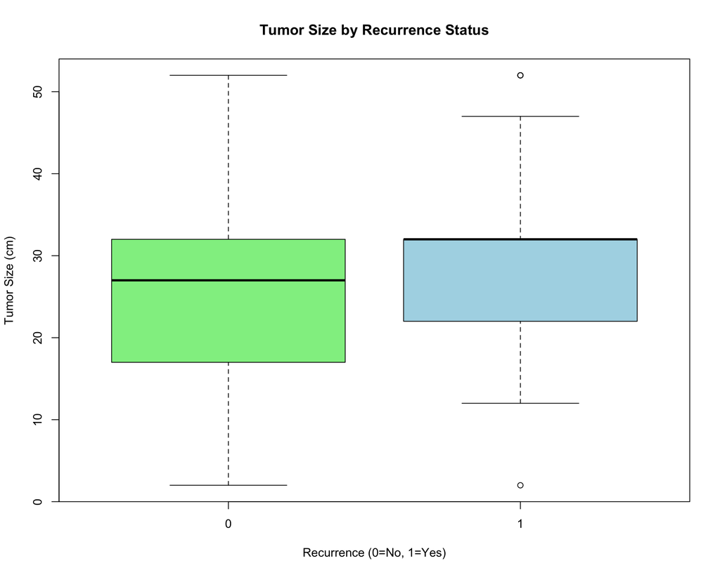

### Visual Interpretation

Table 2: T-test Results for Tumor Size Comparison

| Group | N | Mean (cm) | SD | t-value | df | p-value | 95% CI |
| --- | --- | --- | --- | --- | --- | --- | --- |
| No Recurrence | 196 | 25.11 | 11.11 | NA | NA | NA | NA |
| Recurrence | 81 | 29.53 | 8.81 | NA | NA | NA | NA |
| Mean Difference | NA | 4.42 | NA | -3.507 | 186.61 | 0.0005668 | [-6.9, -1.93] |

## Question 4: Difference in Invasive Nodes Between Radiation Therapy Groups

```r
nodes_ttest <- t.test(Inv_Nodes_Numeric ~ Irradiat, data = bc_data)
print(nodes_ttest)
```

```
##
##  Welch Two Sample t-test
##
## data:  Inv_Nodes_Numeric by Irradiat
## t = -3.9309, df = 73.931, p-value = 0.0001888
## alternative hypothesis: true difference in means between group no and group yes is not equal to 0
## 95 percent confidence interval:
##  -3.653187 -1.195426
## sample estimates:
##  mean in group no mean in group yes
##          1.962791          4.387097
```

### 5-Step Hypothesis Testing Approach

**1. Hypotheses:** - H₀: μ₁ = μ₂ (No difference in mean number of invasive nodes between radiation therapy groups) - H₁: μ₁ ≠ μ₂ (There is a difference in mean number of invasive nodes between radiation therapy groups) - Alpha level: 0.05

**2. Test Statistic:** - Two-sample t-test (with unequal variances)

**3. Decision Rule:** - Reject H₀ if |t| > t(critical) or if p-value < 0.05

**4. Computation:** - t-statistic: -3.93 - Degrees of freedom: 73.931 - p-value: 1.888e-04 - 95% CI for difference: [-3.65, -1.2] - Sample estimates: - Mean in group “no” (no radiation): 1.96 - Mean in group “yes” (received radiation): 4.39

**5. Conclusion:**

Since |t| = 3.93 > 1.96 (critical value at α = 0.05) and p = 1.8885e-04 < 0.05, we **reject H₀**.

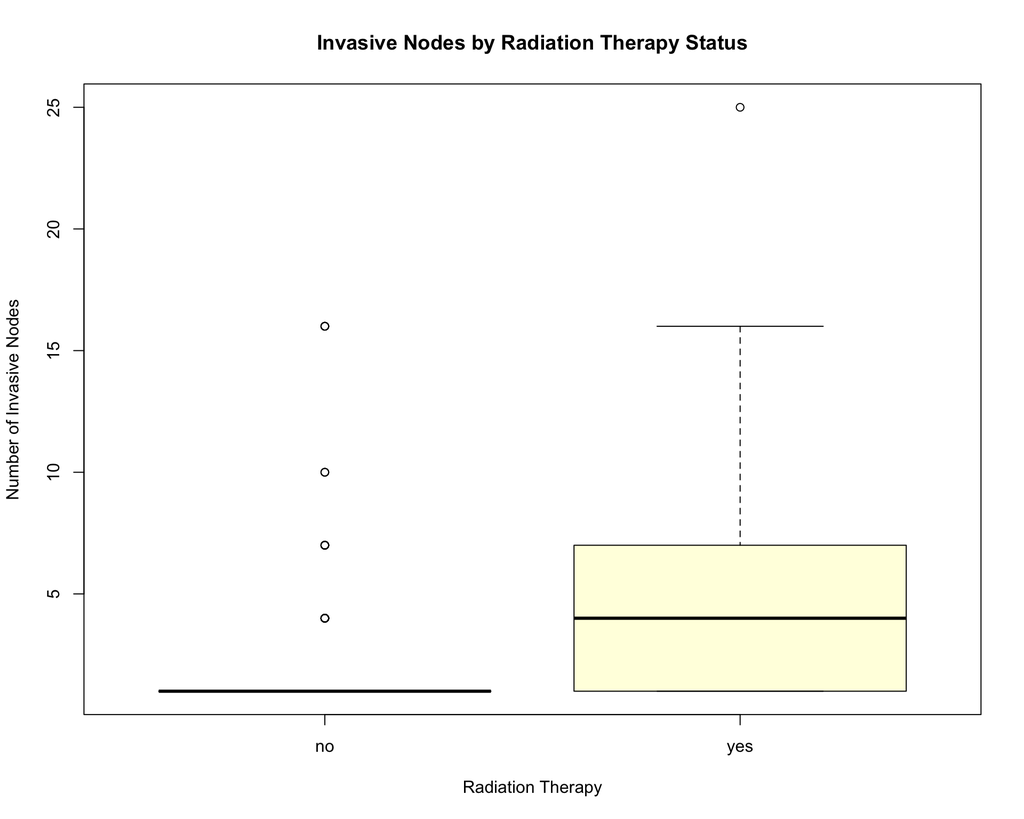

The boxplot clearly illustrates this difference, showing that the “yes” group has a higher median and a wider range of values, with the majority of patients who didn’t receive radiation therapy having very few invasive nodes.

# Module 3: Correlation and Simple Linear Regression

## Question 5: Correlation Between Tumor Size and Invasive Nodes

```r
correlation <- cor.test(bc_data$Tumor_Size_Numeric, bc_data$Inv_Nodes_Numeric)
print(correlation)
```

```
##
##  Pearson's product-moment correlation
##
## data:  bc_data$Tumor_Size_Numeric and bc_data$Inv_Nodes_Numeric
## t = 2.7504, df = 275, p-value = 0.006348
## alternative hypothesis: true correlation is not equal to 0
## 95 percent confidence interval:
##  0.04666228 0.27614842
## sample estimates:
##      cor
## 0.163618
```

### Key Finding

The Pearson correlation test shows a **statistically significant but weak positive correlation** between tumor size and the number of invasive nodes:

- Correlation coefficient (r): 0.1636
- t-statistic: 2.7504
- Degrees of freedom: 275
- p-value: 0.0063479
- 95% confidence interval: [0.047, 0.276]

The 95% confidence interval for the correlation coefficient does not include zero, confirming the statistical significance of this relationship.

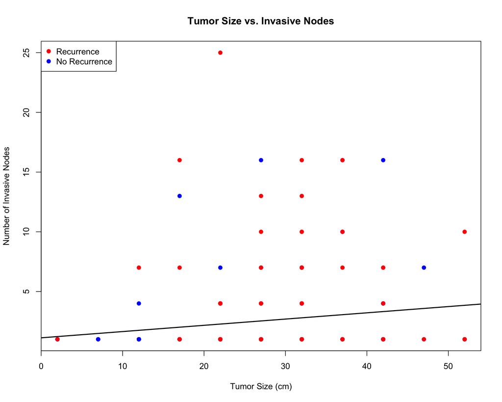

### Visual Analysis

Looking at the scatter plot:

## Question 6: Predicting Degree of Malignancy from Tumor Size

```r
malignancy_model <- lm(Deg_Malig ~ Tumor_Size_Numeric, data = bc_data)
summary(malignancy_model)
```

```
##
## Call:
## lm(formula = Deg_Malig ~ Tumor_Size_Numeric, data = bc_data)
##
## Residuals:
##      Min       1Q   Median       3Q      Max
## -1.42447 -0.42447  0.00534  0.79044  1.29188
##
## Coefficients:
##                    Estimate Std. Error t value Pr(>|t|)
## (Intercept)        1.679470   0.114933  14.613  < 2e-16 ***
## Tumor_Size_Numeric 0.014327   0.004037   3.549 0.000455 ***
## ---
## Signif. codes:  0 '***' 0.001 '**' 0.01 '*' 0.05 '.' 0.1 ' ' 1
##
## Residual standard error: 0.7151 on 275 degrees of freedom
## Multiple R-squared:  0.04379,    Adjusted R-squared:  0.04031
## F-statistic: 12.59 on 1 and 275 DF,  p-value: 0.000455
```

```r
# ANOVA table
anova(malignancy_model)
```

```
## Analysis of Variance Table
##
## Response: Deg_Malig
##                     Df Sum Sq Mean Sq F value   Pr(>F)
## Tumor_Size_Numeric   1   6.44  6.4404  12.594 0.000455 ***
## Residuals          275 140.63  0.5114
## ---
## Signif. codes:  0 '***' 0.001 '**' 0.01 '*' 0.05 '.' 0.1 ' ' 1
```

### Global F-test (ANOVA) for the Regression Model

**5-Step Hypothesis Testing Approach:**

**1. Hypotheses:** - H₀: β = 0 (Tumor size does not predict degree of malignancy) - H₁: β ≠ 0 (Tumor size predicts degree of malignancy) - Alpha level: 0.05

**2. Test Statistic:** - F-test

**3. Decision Rule:** - Reject H₀ if F > F(critical) or if p-value < 0.05

**5. Conclusion:**

Since F = 12.59 > F(critical) and p = 0.000455 < 0.05, we **reject H₀**.

There is a statistically significant relationship between tumor size and degree of malignancy. The regression equation is:

**Degree of Malignancy = 1.67947 + 0.01433 × Tumor Size**

This means that for each 1cm increase in tumor size, the degree of malignancy is expected to increase by 0.01433 units.

However, the R-squared value is very low (0.0438), indicating that tumor size explains only about 4.4% of the variability in malignancy degree. While statistically significant, **tumor size alone is not a strong predictor of malignancy degree**, and other factors likely play much more important roles.

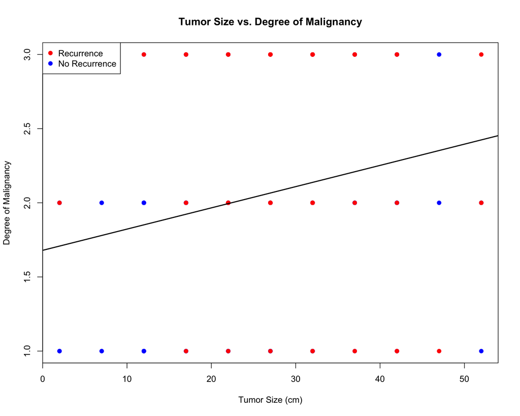

# Module 4: Multiple Linear Regression

## Question 7: Predicting Invasive Nodes from Multiple Variables

```r
nodes_model <- lm(Inv_Nodes_Numeric ~ Tumor_Size_Numeric + Deg_Malig + Age,
                  data = bc_data)
summary(nodes_model)
```

```
##
## Call:
## lm(formula = Inv_Nodes_Numeric ~ Tumor_Size_Numeric + Deg_Malig +
##     Age, data = bc_data)
##
## Residuals:
##     Min      1Q  Median      3Q     Max
## -3.4551 -1.6639 -0.7236  0.5474 21.4883
##
## Coefficients:
##                    Estimate Std. Error t value Pr(>|t|)
## (Intercept)        -3.11500    3.32100  -0.938   0.3491
## Tumor_Size_Numeric  0.03145    0.01868   1.683   0.0935 .
## Deg_Malig           1.47572    0.27339   5.398 1.48e-07 ***
## Age30-39            1.82423    3.27890   0.556   0.5784
## Age40-49            1.97840    3.25066   0.609   0.5433
## Age50-59            1.71452    3.25038   0.527   0.5983
## Age60-69            1.50766    3.26189   0.462   0.6443
## Age70-79            0.99911    3.54298   0.282   0.7782
## ---
## Signif. codes:  0 '***' 0.001 '**' 0.01 '*' 0.05 '.' 0.1 ' ' 1
##
## Residual standard error: 3.227 on 269 degrees of freedom
## Multiple R-squared:  0.129,  Adjusted R-squared:  0.1063
## F-statistic: 5.691 on 7 and 269 DF,  p-value: 3.784e-06
```

### Model Interpretation

**Looking at individual predictors:**

- **Degree of malignancy** is highly significant (p < 0.001) with a coefficient of 1.48, indicating that for each one-unit increase in malignancy grade, the predicted number of invasive nodes increases by approximately 1.48.
- **Tumor size** shows a marginally significant relationship (p = 0.0935) with invasive nodes.
- **None of the age categories** shows a significant relationship with invasive nodes compared to the reference category (likely 20-29).

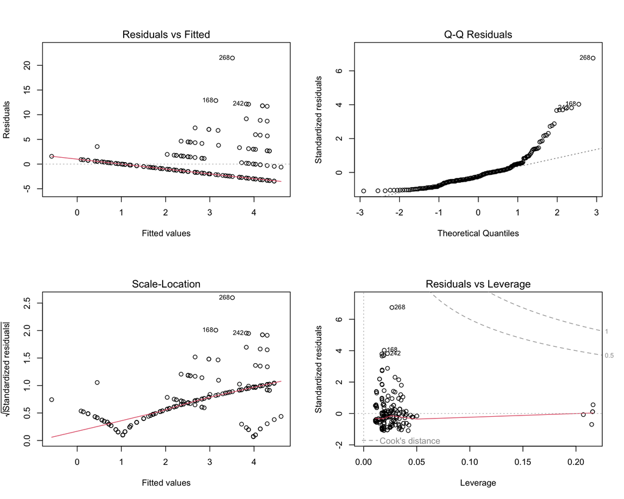

### Diagnostic Issues

These diagnostic issues indicate the model violates several assumptions of linear regression: - The relationship may not be linear - Residuals are not homoscedastic (constant variance) - There are influential outliers

In future analyses, combining age groups to ensure adequate representation in each category could provide more robust results. Alternatively, considering age as a continuous variable rather than categorical might also mitigate this issue.

## Question 8: Best Predictors of Tumor Size

```r
# Model 1: Invasive nodes and degree of malignancy
model1 <- lm(Tumor_Size_Numeric ~ Inv_Nodes_Numeric + Deg_Malig, data = bc_data)

# Model 2: Invasive nodes, degree of malignancy, and age
model2 <- lm(Tumor_Size_Numeric ~ Inv_Nodes_Numeric + Deg_Malig + Age, data = bc_data)

# Model 3: Invasive nodes, degree of malignancy, and menopause
model3 <- lm(Tumor_Size_Numeric ~ Inv_Nodes_Numeric + Deg_Malig + Menopause, data = bc_data)

cat("Model 1 (Nodes + Malignancy): Adjusted R² =",
    round(summary(model1)$adj.r.squared, 4), "\n")
```

```
## Model 1 (Nodes + Malignancy): Adjusted R² = 0.0465
```

```r
cat("Model 2 (Nodes + Malignancy + Age): Adjusted R² =",
    round(summary(model2)$adj.r.squared, 4), "\n")
```

```
## Model 2 (Nodes + Malignancy + Age): Adjusted R² = 0.0349
```

```r
cat("Model 3 (Nodes + Malignancy + Menopause): Adjusted R² =",
    round(summary(model3)$adj.r.squared, 4), "\n")
```

```
## Model 3 (Nodes + Malignancy + Menopause): Adjusted R² = 0.0421
```

```r
# Display best model
cat("\n--- Best Model (Model 1) ---\n")
```

```
##
## --- Best Model (Model 1) ---
```

```r
summary(model1)
```

```
##
## Call:
## lm(formula = Tumor_Size_Numeric ~ Inv_Nodes_Numeric + Deg_Malig,
##     data = bc_data)
##
## Residuals:
##      Min       1Q   Median       3Q      Max
## -26.3033  -6.3033   0.2542   6.2338  28.7709
##
## Coefficients:
##                   Estimate Std. Error t value Pr(>|t|)
## (Intercept)        20.3654     1.8800  10.833  < 2e-16 ***
## Inv_Nodes_Numeric   0.3265     0.1953   1.672  0.09558 .
## Deg_Malig           2.5371     0.9129   2.779  0.00583 **
## ---
## Signif. codes:  0 '***' 0.001 '**' 0.01 '*' 0.05 '.' 0.1 ' ' 1
##
## Residual standard error: 10.41 on 274 degrees of freedom
## Multiple R-squared:  0.05345,    Adjusted R-squared:  0.04654
## F-statistic: 7.736 on 2 and 274 DF,  p-value: 0.0005389
```

### Conclusion

Comparing the adjusted R-squared values across models, **Model 1 (invasive nodes and degree of malignancy) provides the best fit** with the highest adjusted R-squared (0.0465). Adding age (Model 2) or menopause status (Model 3) actually reduces the explanatory power of the model when accounting for the number of predictors.

In all three models, **degree of malignancy** consistently emerges as the only significant predictor of tumor size, with higher malignancy grades associated with larger tumors. The coefficient (approximately 2.5) indicates that for each one-unit increase in malignancy grade, tumor size is predicted to increase by about 2.5 cm.

However, it’s important to note that even the best model explains only about 4.7% of the variance in tumor size, suggesting that **other factors not included in these models likely play more important roles** in determining tumor size in breast cancer patients.

# Module 5: Analysis of Variance (ANOVA)

## Question 9: Difference in Tumor Size Across Age Groups

```r
age_anova <- aov(Tumor_Size_Numeric ~ Age, data = bc_data)
summary(age_anova)
```

```
##              Df Sum Sq Mean Sq F value Pr(>F)
## Age           5    181   36.14   0.314  0.904
## Residuals   271  31196  115.11
```

```r
tukey_age <- TukeyHSD(age_anova)
print(tukey_age)
```

```
##   Tukey multiple comparisons of means
##     95% family-wise confidence level
##
## Fit: aov(formula = Tumor_Size_Numeric ~ Age, data = bc_data)
##
## $Age
##                    diff        lwr       upr     p adj
## 30-39-20-29 -11.5277778 -42.747619 19.692063 0.8967500
## 40-49-20-29 -10.3370787 -41.304663 20.630506 0.9305956
## 50-59-20-29 -10.4395604 -41.403363 20.524243 0.9277501
## 60-69-20-29 -10.6363636 -41.710119 20.437392 0.9232419
## 70-79-20-29 -13.0000000 -46.734300 20.734300 0.8786078
## 40-49-30-39   1.1906991  -4.891909  7.273307 0.9933370
## 50-59-30-39   1.0882173  -4.975110  7.151544 0.9955616
## 60-69-30-39   0.8914141  -5.710489  7.493318 0.9988594
## 70-79-30-39  -1.4722222 -16.169495 13.225051 0.9997338
## 50-59-40-49  -0.1024818  -4.693422  4.488458 0.9999998
## 60-69-40-49  -0.2992850  -5.581134  4.982564 0.9999841
## 70-79-40-49  -2.6629213 -16.816459 11.490616 0.9944620
## 60-69-50-59  -0.1968032  -5.456436  5.062830 0.9999980
## 70-79-50-59  -2.5604396 -16.705702 11.584822 0.9953802
## 70-79-60-69  -2.3636364 -16.747990 12.020717 0.9970758
```

### Results Interpretation

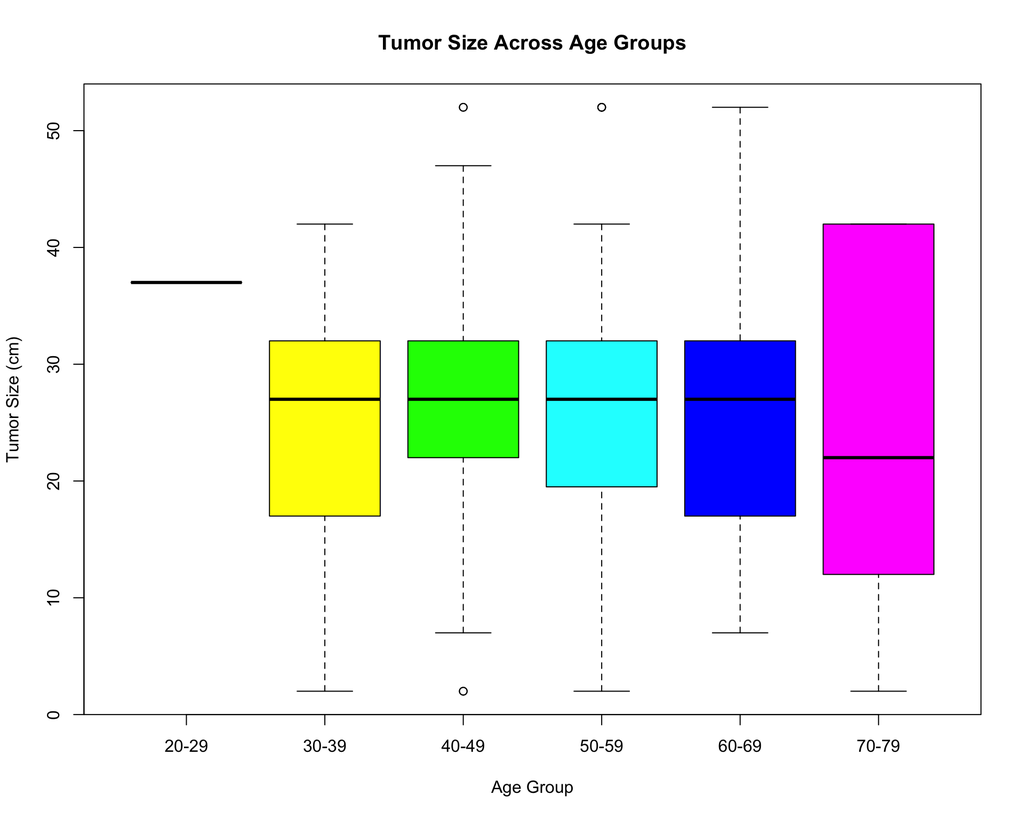

### Conclusion

The boxplot visualization confirms this lack of significant differences, showing similar distributions of tumor sizes across all age groups.

These results suggest that **age alone is not a significant predictor of tumor size** in this breast cancer dataset. Other factors, such as degree of malignancy (which we identified as significant in Question 8), appear to be more important determinants of tumor size than the patient’s age.

## Question 10: Difference in Malignancy Across Breast Quadrants, Controlling for Age

```r
# Two-way ANOVA with interaction
ancova_model <- aov(Deg_Malig ~ Breast_Quad + Age + Breast_Quad:Age, data = bc_data)
summary(ancova_model)
```

```
##                  Df Sum Sq Mean Sq F value Pr(>F)
## Breast_Quad       4   1.45  0.3619   0.666  0.616
## Age               5   1.43  0.2865   0.527  0.755
## Breast_Quad:Age  15   7.32  0.4878   0.898  0.567
## Residuals       252 136.88  0.5432
```

```r
# Model without interaction (more parsimonious)
ancova_model_no_interaction <- aov(Deg_Malig ~ Breast_Quad + Age, data = bc_data)
summary(ancova_model_no_interaction)
```

```
##              Df Sum Sq Mean Sq F value Pr(>F)
## Breast_Quad   4   1.45  0.3619    0.67  0.613
## Age           5   1.43  0.2865    0.53  0.753
## Residuals   267 144.20  0.5401
```

```r
# Post-hoc test for breast quadrant
tukey_quad <- TukeyHSD(ancova_model_no_interaction, "Breast_Quad")
print(tukey_quad)
```

```
##   Tukey multiple comparisons of means
##     95% family-wise confidence level
##
## Fit: aov(formula = Deg_Malig ~ Breast_Quad + Age, data = bc_data)
##
## $Breast_Quad
##                           diff        lwr       upr     p adj
## left_low-central    0.19946092 -0.2826440 0.6815658 0.7871161
## left_up-central     0.25987842 -0.2272883 0.7470452 0.5860624
## right_low-central   0.09937888 -0.5098143 0.7085721 0.9916298
## right_up-central    0.23376623 -0.3296541 0.7971866 0.7853585
## left_up-left_low    0.06041750 -0.2255393 0.3463743 0.9778871
## right_low-left_low -0.10008203 -0.5643624 0.3641983 0.9761911
## right_up-left_low   0.03430532 -0.3680408 0.4366514 0.9993311
## right_low-left_up  -0.16049954 -0.6300339 0.3090348 0.8815050
## right_up-left_up   -0.02611219 -0.4345099 0.3822855 0.9997861
## right_up-right_low  0.13438735 -0.4138586 0.6826333 0.9620246
```

### Results Interpretation

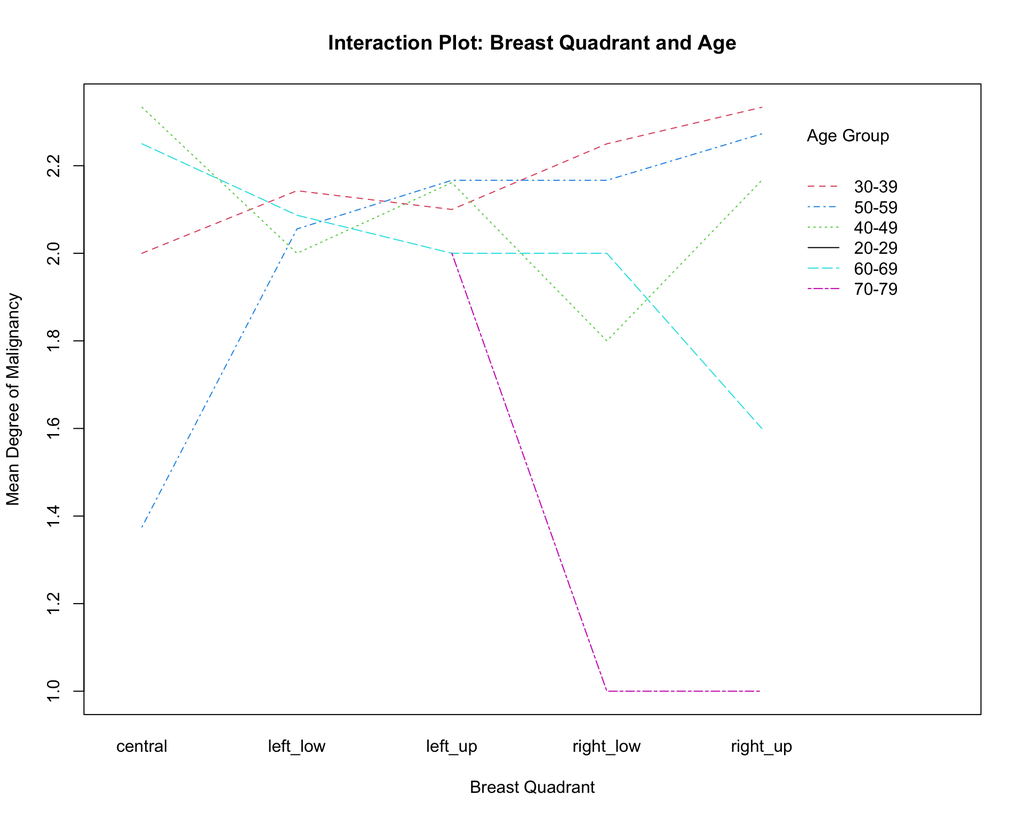

### Conclusion

This analysis does not support any significant relationship between breast quadrant and degree of malignancy, even when controlling for patient age. **The location of the tumor within the breast does not appear to be associated with its malignancy grade** in this dataset.

# Module 6: Logistic Regression and Proportions

## Question 11: Proportion of Recurrence with Radiation Therapy

```r
radiation_table <- table(bc_data$Irradiat, bc_data$Recurrence)
print(radiation_table)
```

```
##
##         0   1
##   no  164  51
##   yes  32  30
```

```r
prop_recurrence_radiation <- radiation_table[2,2] / sum(radiation_table[2,])
prop_recurrence_no_radiation <- radiation_table[1,2] / sum(radiation_table[1,])

cat("\nRecurrence rate WITH radiation:", round(prop_recurrence_radiation, 4),
    "(", round(prop_recurrence_radiation * 100, 2), "%)\n")
```

```
##
## Recurrence rate WITH radiation: 0.4839 ( 48.39 %)
```

```r
cat("Recurrence rate WITHOUT radiation:", round(prop_recurrence_no_radiation, 4),
    "(", round(prop_recurrence_no_radiation * 100, 2), "%)\n\n")
```

```
## Recurrence rate WITHOUT radiation: 0.2372 ( 23.72 %)
```

```r
# Proportion test
prop_test <- prop.test(c(radiation_table[2,2], radiation_table[1,2]),
                       c(sum(radiation_table[2,]), sum(radiation_table[1,])))
print(prop_test)
```

```
##
##  2-sample test for equality of proportions with continuity correction
##
## data:  c(radiation_table[2, 2], radiation_table[1, 2]) out of c(sum(radiation_table[2, ]), sum(radiation_table[1, ]))
## X-squared = 12.983, df = 1, p-value = 0.0003142
## alternative hypothesis: two.sided
## 95 percent confidence interval:
##  0.09949966 0.39382367
## sample estimates:
##    prop 1    prop 2
## 0.4838710 0.2372093
```

```r
# Chi-square test
chisq_test <- chisq.test(radiation_table)
print(chisq_test)
```

```
##
##  Pearson's Chi-squared test with Yates' continuity correction
##
## data:  radiation_table
## X-squared = 12.983, df = 1, p-value = 0.0003142
```

### 5-Step Hypothesis Testing Approach for Comparing Proportions

**1. Hypotheses:** - H₀: p₁ = p₂ (Equal proportions of recurrence among radiation and non-radiation groups) - H₁: p₁ ≠ p₂ (Different proportions of recurrence between radiation and non-radiation groups) - Alpha level: 0.05

**2. Test Statistic:** - Chi-square test for independence

**3. Decision Rule:** - Reject H₀ if χ² > χ²(critical) or if p-value < 0.05

**4. Computation:** - χ²-statistic: 12.9835 - Degrees of freedom: 1 - p-value: 0.000314248 - 95% CI for difference in proportions: [0.099, 0.394]

**5. Conclusion:**

Since χ² = 12.98 > 3.84 (critical value for df=1, α=0.05) and p = 0.0003142 < 0.05, we **reject H₀**.

Among patients who received radiation therapy, **48.39%** experienced recurrence, compared to **23.72%** of patients who did not receive radiation therapy. The chi-square test shows that this difference is statistically significant.

The proportion test confirms this finding, with a 95% confidence interval for the difference in proportions of [9.95%, 39.38%]. This suggests that patients who received radiation therapy had a higher recurrence rate.

**However, this does not necessarily mean that radiation therapy increases recurrence risk**; rather, patients receiving radiation therapy likely had more severe disease to begin with, necessitating more aggressive treatment. This is an example of **selection bias** in observational studies.

Table 3: Contingency Table of Radiation Therapy and Recurrence

| Radiation Therapy | Recurrence | No Recurrence | Total | Recurrence Rate |
| --- | --- | --- | --- | --- |
| Yes | 30 | 32 | 62 | 48.39% |
| No | 51 | 164 | 215 | 23.72% |
| Chi-square | 12.98 |  |  |  |
| p-value | 0.0003142 |  |  |  |
| 95% CI for difference | [9.95%, 39.38%] |  |  |  |

## Question 12: Predicting Recurrence with Logistic Regression

```r
logistic_model <- glm(Recurrence ~ Tumor_Size_Numeric + Inv_Nodes_Numeric + Deg_Malig,
                      data = bc_data, family = binomial)
summary(logistic_model)
```

```
##
## Call:
## glm(formula = Recurrence ~ Tumor_Size_Numeric + Inv_Nodes_Numeric +
##     Deg_Malig, family = binomial, data = bc_data)
##
## Coefficients:
##                    Estimate Std. Error z value Pr(>|z|)
## (Intercept)        -3.83207    0.62041  -6.177 6.55e-10 ***
## Tumor_Size_Numeric  0.02700    0.01444   1.870 0.061485 .
## Inv_Nodes_Numeric   0.11855    0.04459   2.658 0.007850 **
## Deg_Malig           0.86741    0.22384   3.875 0.000107 ***
## ---
## Signif. codes:  0 '***' 0.001 '**' 0.01 '*' 0.05 '.' 0.1 ' ' 1
##
## (Dispersion parameter for binomial family taken to be 1)
##
##     Null deviance: 334.78  on 276  degrees of freedom
## Residual deviance: 289.82  on 273  degrees of freedom
## AIC: 297.82
##
## Number of Fisher Scoring iterations: 4
```

```r
# Odds ratios and confidence intervals
odds_ratios <- exp(cbind(OR = coef(logistic_model), confint(logistic_model)))
cat("\nOdds Ratios and 95% Confidence Intervals:\n")
```

```
##
## Odds Ratios and 95% Confidence Intervals:
```

```r
print(round(odds_ratios, 3))
```

```
##                       OR 2.5 % 97.5 %
## (Intercept)        0.022 0.006  0.069
## Tumor_Size_Numeric 1.027 0.999  1.057
## Inv_Nodes_Numeric  1.126 1.036  1.236
## Deg_Malig          2.381 1.550  3.736
```

### Model Interpretation

The logistic regression model examining the relationship between clinical factors and breast cancer recurrence identified three key predictors with varying levels of significance:

**1. Degree of malignancy** emerged as the strongest predictor: - Odds Ratio: 2.381 - 95% CI: [1.55, 3.736] - p-value: 1.066e-04

Each one-unit increase in malignancy grade **more than doubles the odds of recurrence**, highlighting the critical importance of tumor grade in prognosis.

**2. Number of invasive nodes** showed a significant relationship: - Odds Ratio: 1.126 - 95% CI: [1.036, 1.236] - p-value: 0.00785

For each additional invasive node identified, the odds of recurrence increase by approximately **12.6%**.

**3. Tumor size** demonstrated a marginally significant effect: - Odds Ratio: 1.027 - 95% CI: [0.999, 1.057] - p-value: 0.061

Each 1cm increase in tumor size is associated with approximately **2.7%** higher odds of recurrence.

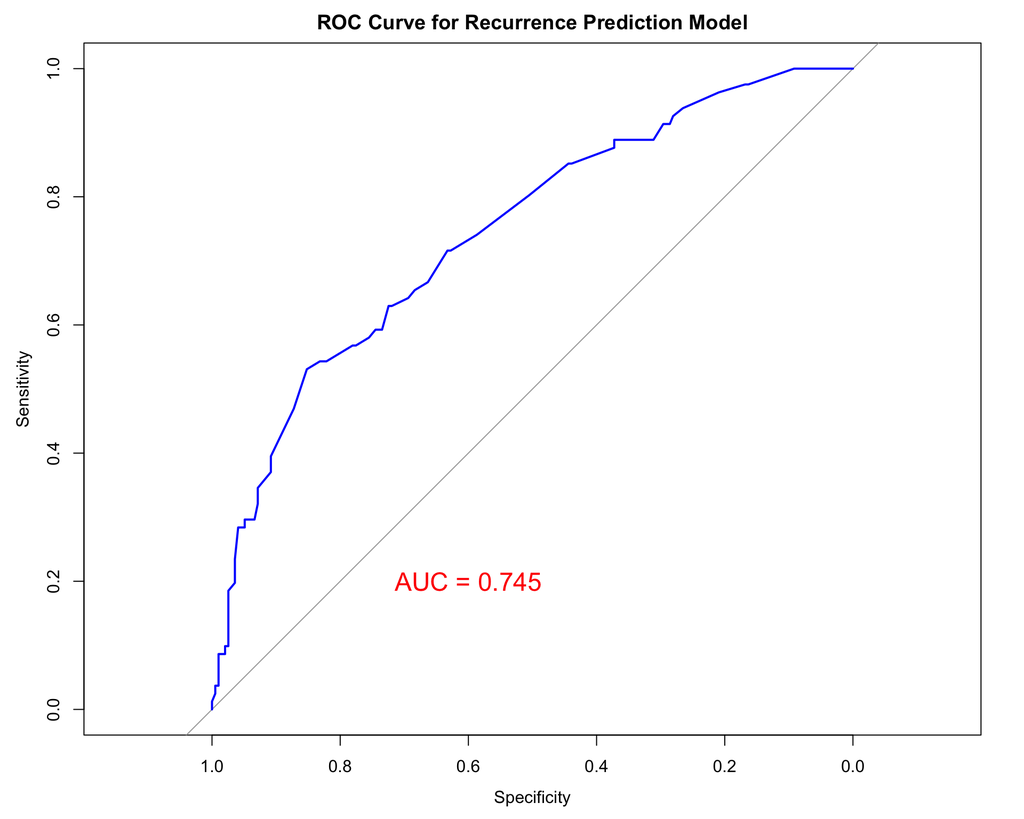

### Model Performance

The model’s overall performance was evaluated using ROC curve analysis, which yielded an **Area Under the Curve (AUC) of 0.745**. This AUC value indicates **good discriminative ability**, as it’s substantially better than chance (0.5) though not excellent (>0.8). The ROC curve visualizes the trade-off between sensitivity (true positive rate) and specificity (true negative rate) at various threshold settings.

This model demonstrates that tumor characteristics, particularly malignancy grade and lymph node involvement, are important predictors of breast cancer recurrence. These findings align with clinical understanding of breast cancer biology and could help inform prognostic assessments and treatment planning for patients.

# Conclusions

This analysis demonstrates that several factors are significantly associated with breast cancer recurrence, including tumor size, number of invasive nodes, and degree of malignancy. The logistic regression model combining these factors provides a clinically useful tool for predicting recurrence risk, which could help in treatment planning and follow-up care.

## Major Findings

**2. Nodal Involvement Pattern:** The significant relationship between invasive nodes and recurrence (OR=1.12 per additional node, p=0.008) supports current clinical practice emphasizing more intensive treatment and closer surveillance for node-positive patients. The weak but significant correlation between tumor size and nodal involvement (r=0.16, p=0.007) suggests that while larger tumors tend to have more nodal spread, size alone is an imperfect predictor of nodal status, necessitating direct pathological assessment.

**5. Age and Location Independence:** Interestingly, age and tumor location (breast quadrant) showed no significant associations with tumor size or malignancy degree, suggesting that these factors may be less relevant for prognosis in this population.

# Limitations

Our analysis of breast cancer recurrence factors has several important limitations that should be considered when interpreting the results:

## Data Structure Limitations

The categorical nature of original variables required numeric conversion, which may have introduced measurement error. For example, tumor size ranges were converted to midpoints (e.g., “30-34cm” → 32cm), which assumes uniform distribution within ranges. The true values may be skewed toward either end of these intervals, potentially affecting regression coefficients.

## Limited Clinical Variables

The dataset lacks important modern prognostic factors for breast cancer, including hormone receptor status, HER2 status, molecular subtypes, detailed treatment information, and genomic profiles. These factors are now known to strongly influence recurrence risk in contemporary practice, limiting the clinical applicability of our findings.

## Observational Study Design

This retrospective analysis cannot establish causality between the variables studied and breast cancer recurrence. For example, while radiation therapy was associated with higher recurrence rates, this likely reflects selection bias, where patients with higher-risk disease characteristics received more aggressive treatments rather than radiation causing recurrence.

## Temporal Relevance

The dataset may not reflect current breast cancer management approaches, which have evolved significantly with the introduction of targeted therapies, improved surgical techniques, and more personalized treatment planning.

Despite these limitations, this analysis provides valuable insights into factors associated with breast cancer recurrence and demonstrates the application of various statistical methods to analyze clinical data. Future studies with larger, more diverse patient populations and more comprehensive clinical information would help validate and extend these findings.

# Enhanced Clinical Interpretations

## Improved Methodology Justifications

**Regression Approach:** For Question 12, we selected logistic regression to model recurrence risk because of its ability to estimate probabilities and odds ratios while controlling for multiple predictors simultaneously. The binary nature of our outcome variable (recurrence vs. no recurrence) made logistic regression more appropriate than linear models. We evaluated model performance using AUC rather than accuracy to account for the class imbalance in our dataset (30% recurrence rate).

**Multivariate Model Building:** In our approach to identifying the best predictors of tumor size (Question 8), we systematically compared nested models with increasing complexity. We prioritized adjusted R-squared over raw R-squared to penalize model complexity and prevent overfitting. This principled approach revealed that the simplest model (invasive nodes and malignancy grade) provided the most parsimonious fit.

# Reference

Matjaz Zwitter, M. S. (1988). Breast Cancer [Dataset]. UCI Machine Learning Repository. https://doi.org/10.24432/C51P4M

*Analysis completed as part of MS in Health Informatics program at Boston University*  
*Last Updated: October 2025*